# Cluster quality control

Nadine Bestard

28/05/2021

## set up

```r
library(SingleCellExperiment)
library(here) # reproducible paths
```

```r
library(scater) # plot reduced dims
library(dplyr) # df filtering
age <- "old"
```

### Number of molecules per cluster

```r
sce <- readRDS(here("processed", age, "sce_clusters.RDS"))
```

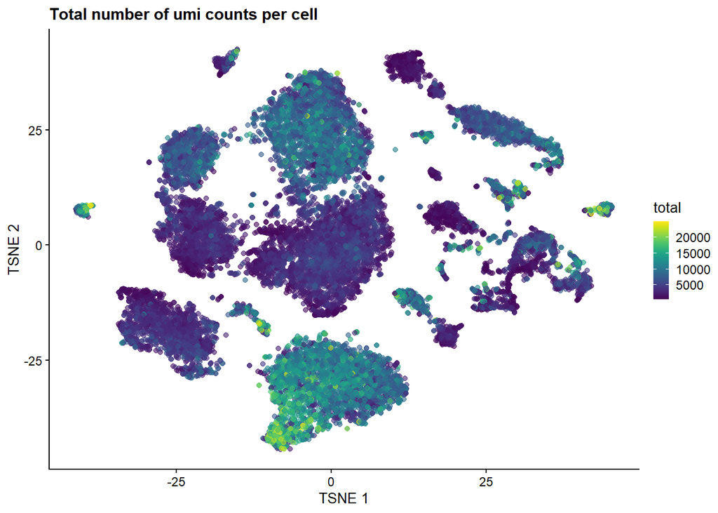

```r
plotTSNE(sce, colour_by = "total") +
  ggtitle("Total number of umi counts per cell")
```

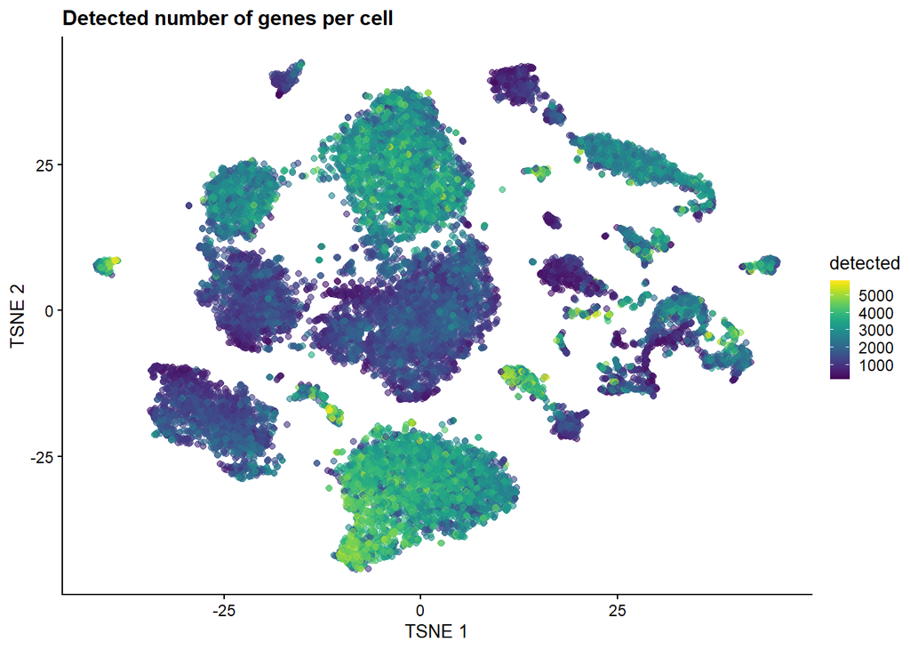

```r
plotTSNE(sce, colour_by = "detected") +
  ggtitle("Detected number of genes per cell")
```

Lower values of umi counts and detected genes can be associated to lower quality cells. Cells can also have lower expressed genes due to their biological state or celltype.

```r
pct_cells<- 50
min_umi  <- 3000
```

Select clusters with 50 % cells having less than 3000umi counts.

```r
umi_df <- as.data.frame(cbind(sce$total, sce$cluster_k60))
colnames(umi_df) <- c("umi", "cluster_k60")

# caculate the percentatges of cells that are "low umi"
umi_df <-
  umi_df %>%
  mutate(low_umi = umi < min_umi) %>%
  group_by(cluster_k60) %>%
  summarise(n_low_umi = sum(low_umi), n_cells = n()) %>%
  mutate(pct_cell_low_umi = (n_low_umi/n_cells)*100)
umi_df %>% arrange(desc(pct_cell_low_umi))
```

| cluster_k60 | n_low_umi | n_cells | pct_cell_low_umi |
| --- | --- | --- | --- |
| 17 | 93 | 96 | 96.8750000 |
| 21 | 381 | 395 | 96.4556962 |
| 13 | 319 | 377 | 84.6153846 |
| 4 | 188 | 291 | 64.6048110 |
| 15 | 191 | 363 | 52.6170799 |
| 8 | 768 | 1609 | 47.7315103 |
| 24 | 52 | 112 | 46.4285714 |
| 2 | 248 | 555 | 44.6846847 |
| 7 | 82 | 213 | 38.4976526 |
| 9 | 568 | 1624 | 34.9753695 |

[output cut: 14 more lines]

```r
# Filter the clusters that have a high proportion of "low umi"
low_umi_clusters <-
  umi_df %>%
  filter(pct_cell_low_umi > pct_cells) %>%
  .$cluster_k60
```

The clusters flagged are 4, 13, 15, 17, 21

### Mithocondrial genes

High mithocondrial genes is associated with stressed, lower quality, cells.

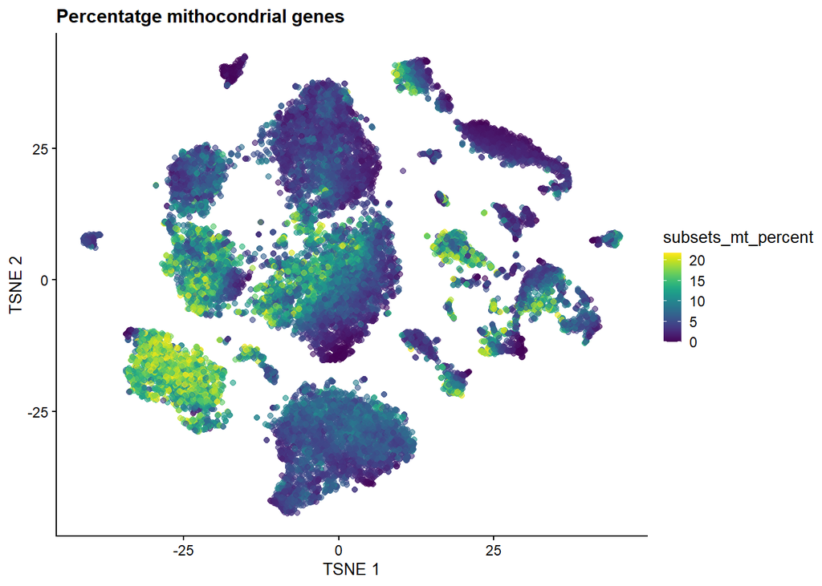

```r
plotTSNE(sce, colour_by = "subsets_mt_percent") +
  ggtitle("Percentatge mithocondrial genes")
```

```r
pct_cells<- 50
pct_mt  <- 10
```

Select clusters with 50 % cells having more than 10% mithocondrial genes.

```r
mt_df <- as.data.frame(cbind(sce$subsets_mt_percent, sce$cluster_k60))
colnames(mt_df) <- c("subsets_mt_percent", "cluster_k60")

mt_df <-
  mt_df %>%
  mutate(high_pct = subsets_mt_percent > pct_mt) %>%
  group_by(cluster_k60) %>%
  summarise(n_high_mt = sum(high_pct), n_cells = n()) %>%
  mutate(pct_cell_high_mt = (n_high_mt/n_cells)*100)
mt_df %>% arrange(desc(pct_cell_high_mt))
```

| cluster_k60 | n_high_mt | n_cells | pct_cell_high_mt |
| --- | --- | --- | --- |
| 9 | 1478 | 1624 | 91.0098522 |
| 13 | 227 | 377 | 60.2122016 |
| 8 | 849 | 1609 | 52.7656930 |
| 18 | 66 | 164 | 40.2439024 |
| 4 | 116 | 291 | 39.8625430 |
| 2 | 219 | 555 | 39.4594595 |
| 15 | 124 | 363 | 34.1597796 |
| 6 | 969 | 3510 | 27.6068376 |
| 21 | 103 | 395 | 26.0759494 |
| 17 | 22 | 96 | 22.9166667 |

[output cut: 14 more lines]

```r
high_mt_clusters <-
  mt_df %>%
  filter(pct_cell_high_mt > pct_cells) %>%
  .$cluster_k60
```

The clusters flagged are 8, 9, 13.

### Number of mice per cluster

How many mice contribute to each cluster?

```r
# count how many cells from each gnt group  there are per cluster
sum_per_gnt_cluster <- table(sce$genotype, sce$cluster_k60 )
# for each cluster count how many cells are from each mice, dividing by KO and WT mice
sum_per_mice_cluster <- table(sce$mouse, sce$genotype, sce$cluster_k60 )
# For each cluster sum of mice that do have cells on that cluster
colSums(sum_per_mice_cluster > 0)
```

```
##
##      1 2 3 4 5 6 7 8 9 10 11 12 13 14 15 16 17 18 19 20 21 22 23 24
##   KO 3 3 3 3 3 3 3 3 3  3  3  3  3  3  3  3  3  3  3  3  1  3  3  0
##   WT 3 3 3 3 3 3 3 3 3  3  3  3  3  3  3  3  3  3  3  3  3  3  3  3
```

```r
# create a summary
summary <- as.data.frame(rbind(colSums(sum_per_mice_cluster > 0), sum_per_gnt_cluster, colSums(sum_per_gnt_cluster)))
row.names(summary) <- c("KO mice", "WT mice", "KO cells", "WT cells", "total cells")
summary
```

|  | 1 | 2 | 3 | 4 | 5 | 6 | 7 | 8 | 9 | 10 | 11 | 12 | 13 | 14 | 15 | 16 | 17 | 18 | 19 | 20 | 21 | 22 | 23 | 24 |
| --- | --- | --- | --- | --- | --- | --- | --- | --- | --- | --- | --- | --- | --- | --- | --- | --- | --- | --- | --- | --- | --- | --- | --- | --- |
| KO mice | 3 | 3 | 3 | 3 | 3 | 3 | 3 | 3 | 3 | 3 | 3 | 3 | 3 | 3 | 3 | 3 | 3 | 3 | 3 | 3 | 1 | 3 | 3 | 0 |
| WT mice | 3 | 3 | 3 | 3 | 3 | 3 | 3 | 3 | 3 | 3 | 3 | 3 | 3 | 3 | 3 | 3 | 3 | 3 | 3 | 3 | 3 | 3 | 3 | 3 |
| KO cells | 7 | 315 | 1119 | 153 | 238 | 1249 | 193 | 507 | 950 | 70 | 121 | 1815 | 254 | 241 | 230 | 22 | 32 | 74 | 139 | 270 | 1 | 112 | 263 | 0 |
| WT cells | 800 | 240 | 1571 | 138 | 70 | 2261 | 20 | 1102 | 674 | 67 | 40 | 941 | 123 | 139 | 133 | 180 | 64 | 90 | 142 | 207 | 394 | 161 | 580 | 112 |
| total cells | 807 | 555 | 2690 | 291 | 308 | 3510 | 213 | 1609 | 1624 | 137 | 161 | 2756 | 377 | 380 | 363 | 202 | 96 | 164 | 281 | 477 | 395 | 273 | 843 | 112 |

Except from the obvious microglia clusters, where the numbers are very low or even absent in the fire mice nothing stands out.

### Control vs fire mice

We want to make sure that the differences in the quality are not due to the fact the mice are KO before deleting the clusters

```
## which will replace the existing scale.
## which will replace the existing scale.
```

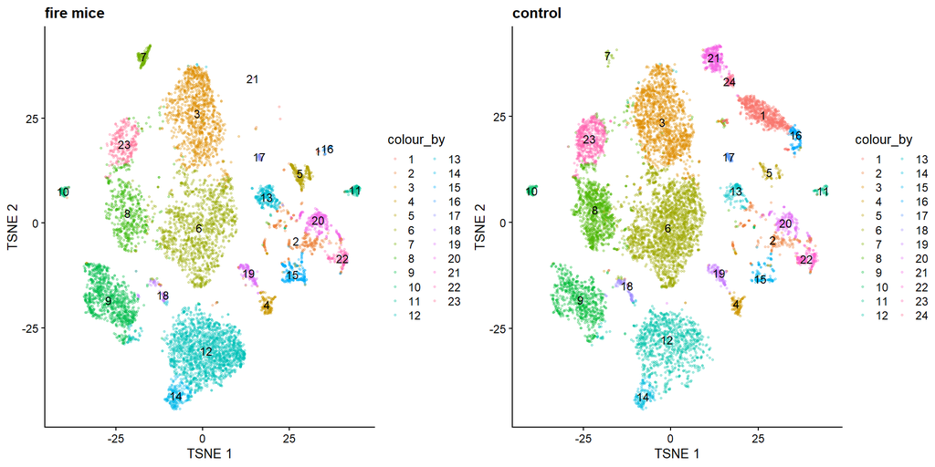

```r
# divide the two objects
sce_ko <- sce[,sce$genotype == "KO"]
sce_ctr <- sce[,sce$genotype == "WT"]
# plot them side by side
gridExtra::grid.arrange(
plotTSNE(sce_ko, colour_by = "cluster_k60", point_size=0.5,
         point_alpha = 0.3, text_by = "cluster_k60", text_size = 3) +
  scale_color_hue() +
  ggtitle("fire mice"),
plotTSNE(sce_ctr, colour_by = "cluster_k60", point_size=0.5,
         point_alpha = 0.3, text_by = "cluster_k60", text_size = 3) +
  scale_color_hue() +
  ggtitle("control"),
ncol = 2
)
```

#### Proportion KO-WT

Visualise the proportions in a table

```r
prop_per_gnt <- round(prop.table(sum_per_gnt_cluster, margin = 2 )*100, 2)

prop_per_gnt<- as.data.frame(prop_per_gnt)
colnames(prop_per_gnt) <- c("Genotype", "cluster", "Proportion")

prop_per_gnt %>%
  arrange(desc(Proportion))
```

| Genotype | cluster | Proportion |
| --- | --- | --- |
| WT | 24 | 100.00 |
| WT | 21 | 99.75 |
| WT | 1 | 99.13 |
| KO | 7 | 90.61 |
| WT | 16 | 89.11 |
| KO | 5 | 77.27 |
| KO | 11 | 75.16 |
| WT | 23 | 68.80 |
| WT | 8 | 68.49 |
| KO | 13 | 67.37 |

[output cut: 38 more lines]

visualise in a plot

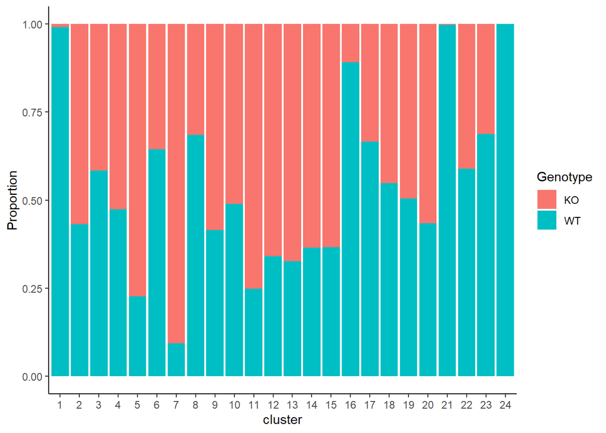

```r
ggplot(data = prop_per_gnt, aes(x = cluster, y = Proportion, fill = Genotype)) +
  geom_bar(position = "fill", stat = "identity") + theme_classic()
```

```r
ko_wt_pct <- 60
```

We consider that if the difference between the two groups is greater than 60 the cluster might be different due to a biological condition and it is better to not remove them for now even if they have high mithocondrial genes or low umi counts.

```r
difference_KO_WT <-
  prop_per_gnt %>%
  arrange(desc(Proportion)) %>%
# the microglia clusters will be the top differences, but this is not
    # something we are specially interested
  filter(!(cluster %in% c(21, 24, 1, 16))) %>%
      # we can take the top 20, as the next 20 is duplicated info
    # all clusters are duplicated ( ex: 40 % in WT, 60 % KO)
  slice_head(n = 20) %>%
    # select the "interesting" clusters
  filter(Proportion > ko_wt_pct ) %>%
  .$cluster
```

### Cluster QC

We then filter out the clusters highlighted as low umi, or high mt but do not have a big difference between control and treatment.

```
## which will replace the existing scale.
```

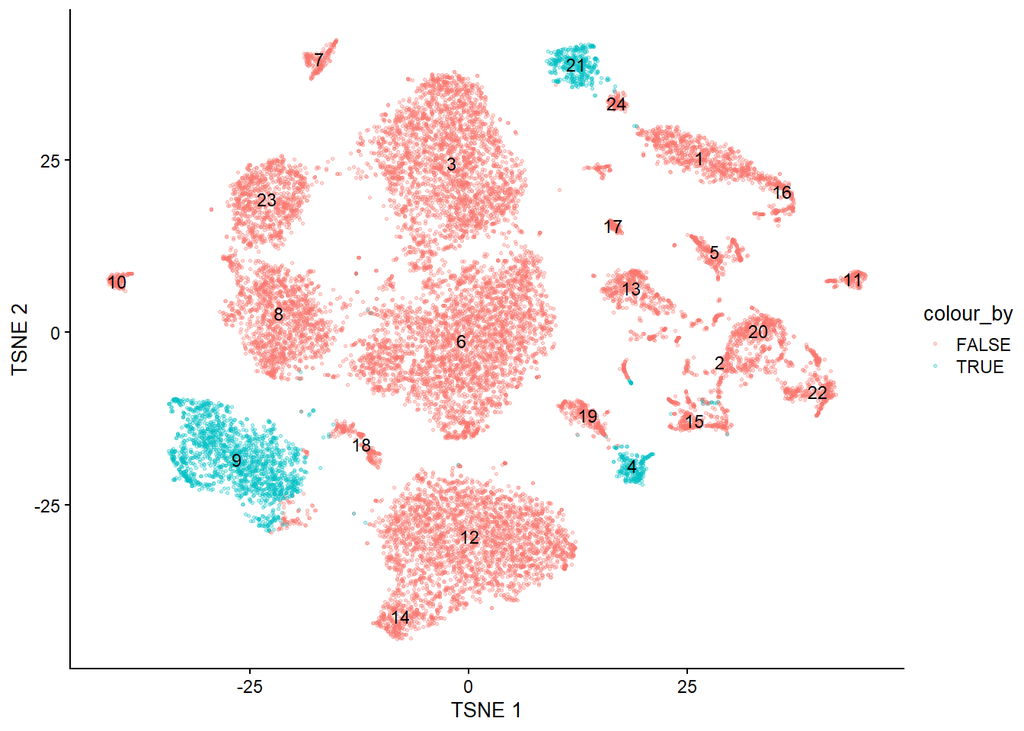

```r
sce$filter_out <- sce$cluster_k60 %in% c( high_mt_clusters, low_umi_clusters) &
                !(sce$cluster_k60 %in% difference_KO_WT)
plotTSNE(sce, colour_by = "filter_out", point_size=0.5,
         point_alpha = 0.3, text_by = "cluster_k60", text_size = 3) +
  scale_color_hue()
```